```python
%matplotlib inline
import matplotlib.pyplot as plt
import numpy as np
import pandas as pd
import seaborn
plt.rcParams['axes.labelsize'] = 22
```

# Estimating the underlying distributtion from correlations in $\Delta\dot{\nu}$ and $|\dot{\nu}|$

In the [supplementary material](http://www.sciencemag.org/content/329/5990/408/suppl/DC1) of [Lyne (2010)](http://www.sciencemag.org/content/329/5990/408.full.pdf) the authors noted correlation between the $\log$ values of the fractional amplitude $\Delta\dot\nu$ (which they interpreted as the switching magnitude) and the pulsars spin-down rate $|\dot{\nu}|$.

## Reproduce the correlation

First let's reproduce the result, here is the data from Table 1:

```python
nu = [1.229, 1.616, 1.543, 10.4, 1.3, 2.579, 2.622, 1.410, 2.631, 1.672,
      3.952, 1.524, 0.983, 2.469, 3.256, 2.322, 5.996, 3.728]

nudot = [-21.25, -12.05, -11.76, -135.36, -88.31, -11.84, -7.5, -1.75, -1.18,
         -17.7, -3.59, -22.75, -5.33, -365.68, -58.85, -73.96, -604.36, -58.64]

Deltanudot_over_nudot_percent = [44.9, 13.28, 6.8, 5.91, 3.28, 2.52, 2.0, 1.71,
                         1.69, 0.85, 0.84, 0.79, 0.75, 0.71, 0.68, 0.68, 0.66,
                         0.31]
```

Now turn into into S.I units and calculate the $\Delta\dot{\nu}$ from the fractional size

```python
Deltanudot_over_nudot = np.array(Deltanudot_over_nudot_percent) / 100.0

nudot = 1e-15 * np.array(nudot)
Deltanudot = Deltanudot_over_nudot * np.abs(nudot)
```

### Plot the data

```
Correlation coefficient of 0.768
```

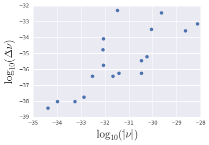

```python
xobs = np.log(np.abs(nudot))
yobs = np.log(np.abs(Deltanudot))

p = np.corrcoef(xobs, yobs)[0, 1]
print("Correlation coefficient of {:1.3f}".format(p))

fig, ax = plt.subplots()
ax.plot(xobs, yobs, "o")
ax.set_xlabel(r"$\log_{10}(|\dot{\nu}|)$")
ax.set_ylabel(r"$\log_{10}(\Delta\dot{\nu})$")
plt.show()
```

This seems to agree with what was found by Lyne (2010), although they had an extra 51 data points from (S2).

## Precession intepretation

If the variations are caused not by switching, but instead by precession, then the time-dependent spin-down modulatoin is given by

$$ \Delta\dot{\nu}(t) = \frac{1}{2\pi\tau_A P} \left(2\theta\cot\chi\sin\psi(t) - \frac{\theta^{2}}{2}\cos2\psi(t)\right) $$

The $\Delta\dot{\nu}$ considered in the previous plot are the peak-to-peak values. Solving for the extrema we calculate (see the end of this notebook) that the precession predicts the peak-to-peak amplitude to be

$$ |\Delta\dot{\nu}| = \frac{1}{2\pi\tau_A P} \left(\left|2\theta\cot\chi\right| + \theta^{2} + \cot^{2}\chi\right) $$

### Quick numerical check:

Here is a quick numerical experiment to ensure that this equation holds up

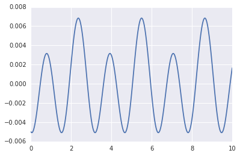

```
0.0119254746931
0.0119254990018
```

```python
def f(t, psidot, theta, chi):
    psi = t *psidot
    return 2*theta*np.cos(chi)/np.sin(chi)*np.sin(psi) - 0.5*theta**2*np.cos(2*psi)

times = np.linspace(0, 10, 1000)
psidot = 2
theta = 0.1
chi = 1.58
y = f(times, psidot, theta, chi)
plt.plot(times, y)
plt.show()

print y.max() - y.min()
print abs(2*theta*np.cos(chi)/np.sin(chi)) + theta**2 + (np.cos(chi)/np.sin(chi))**2
```

## Predicting the underlying $\theta$ and $\chi~$

Let's first rewrite the prediction for $\Delta\dot{\nu}$ as a function of $\nu$ as follows:

\begin{align} |\Delta\dot{\nu}| & = \frac{1}{2\pi\tau_A P} \left(\left|2\theta\cot\chi\right| + \theta^{2} + \cot^{2}\chi\right) \\ & = \frac{1}{2\pi}\frac{|\dot{\nu}|}{\nu}\nu \left(\left|2\theta\cot\chi\right| + \theta^{2} + \cot^{2}\chi\right) \\ & = \frac{1}{2\pi}|\dot{\nu}| \left(\left|2\theta\cot\chi\right| + \theta^{2} + \cot^{2}\chi\right) \\ \end{align}

Now we can fit this model to the observed values to derive the underlying distribution of $\theta$ and $\chi$.

### Fitting the distribution

To fit the distribution we use linear regression with the offset defined as above. We will use a uniform prior on $\theta$ and $\chi$ over $[0, \pi]$ and a uniform prior on the noise-parameter $\epsilon$ of $[0, 10]$.

```python
import pymc3 as pm

with pm.Model() as model:
    theta = pm.Uniform('theta', lower=0.0, upper=np.pi)
    chi = pm.Uniform('chi', lower=0.0, upper=np.pi)
    eps = pm.Uniform('eps', lower=0.0, upper=10)

    mu = xobs + pm.log((pm.sqrt((2*theta*pm.cos(chi)/pm.sin(chi))**2)
                        + theta**2 + (pm.cos(chi)/pm.sin(chi))**2)/(2*np.pi))/np.log(10)

    # Likelihood (sampling distribution) of observations
    Y_obs = pm.Normal('Y_obs', mu=mu, sd=eps, observed=yobs)
```

Run the MCMC simulations

```python
nsamples = 100000
nburn = 10000
with model:
    step = pm.Metropolis()
    trace = pm.sample(nsamples, step, progressbar=True)
```

```
 [-----------------100%-----------------] 100000 of 100000 complete in 40.2 sec
```

#### Plot the estimated posterior distribution and traces:

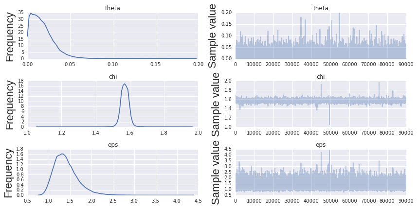

```python
pm.traceplot(trace[nburn:])
plt.show()
```

#### Corner plot

[output not shown]

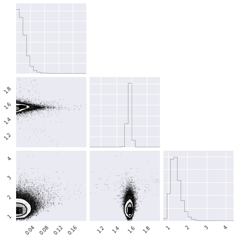

```python
from triangle import corner
theta_chain = trace[nburn:]['theta']
chi_chain = trace[nburn:]['chi']
eps_chain = trace[nburn:]['eps']
data = np.vstack((theta_chain, chi_chain, eps_chain)).T
corner(data)
plt.show()
```

#### Plot 100 realisations with the data

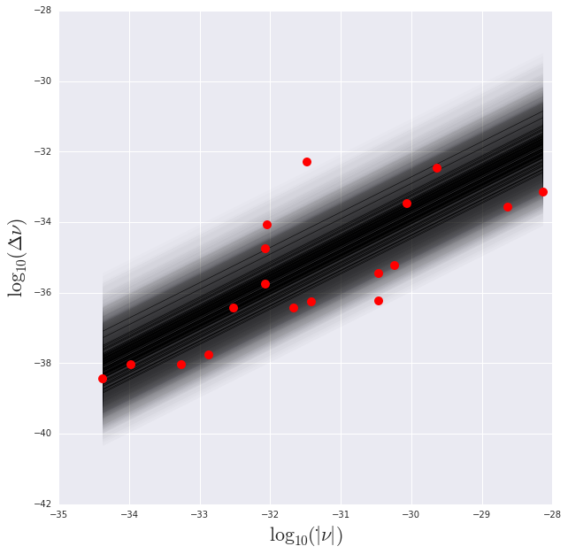

```python
npp = 100
repeats = 100
fig, ax = plt.subplots(figsize=(10, 10))
xfit = np.linspace(xobs.min(), xobs.max(), 100)

for i  in np.arange(0, npp, 1):
    s = trace[np.random.randint(nburn, nsamples)]
    chi = s['chi']
    theta = s['theta']
    cotchi = np.cos(chi)/np.sin(chi)
    eps = s['eps']
    yfit = xfit + np.log10((np.abs(2*theta*cotchi) + theta**2 + cotchi**2)/(2*np.pi))
    ax.plot(xfit, yfit, "-", lw=0.5, color='k')
    ax.fill_between(xfit, yfit-eps, yfit+eps, alpha=0.01, color='k')

ax.plot(xobs, yobs, "o", color='r', markersize=10)
ax.set_xlabel(r"$\log_{10}(|\dot{\nu}|)$")
ax.set_ylabel(r"$\log_{10}(\Delta\dot{\nu})$")

plt.show()
```

## Derivation of peak-to-peak amplitude

If we define

$$ y = A \sin(x) - B\cos(2x) $$

It can be shown that this has four extrema in $[0, 2\pi]$ which are

$$ x = \sin^{-1}\left(\frac{-A}{4B}\right), \; \pi - \sin^{-1}\left(\frac{-A}{4B}\right), \; \frac{\pi}{2}, \; \frac{3\pi}{2} $$

Let's check this (and help decide which is which):

```
Actual dy = 2.756, predicted df = 2.756
```

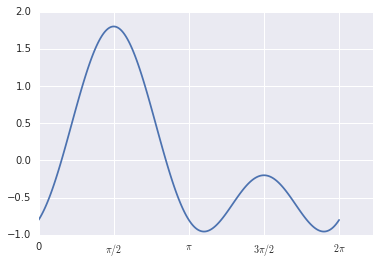

```python
def y(x, A, B):
    return A*np.sin(x) - B*np.cos(2*x)

x = np.linspace(0, 2*np.pi, 1000)
A = 1
B = 0.8

fig, ax = plt.subplots()
yplot = y(x, A, B)
ax.plot(x, yplot)

ax.set_xticks([0, np.pi/2, np.pi, 3*np.pi/2, 2*np.pi])
ax.set_xticklabels(["0", "$\pi/2$", "$\pi$", "$3\pi/2$", "$2\pi$"])

actual_dy = yplot.max() - yplot.min()
predic_dy = abs(A) + 2*B + A**2 / (8*B)
print "Actual dy = {:1.3f}, predicted df = {:1.3f}".format(actual_dy, predic_dy)
plt.show()
```

From this it is clear the last two solutions correspond to the maxima while the other two correspond to the minima. Then let's calculate the peak-to-peak amplitude. The two minima are always equal, so we have two peak-to-peak amplitudes to consider:

$$ \Delta y_1 = A + 2B + \frac{A^{2}}{8B} $$

and

$$ \Delta y_2 = -A + 2B + \frac{A^{2}}{8B} $$

The second value will be larger if $A<0$, so we can write the general peak-to-peak amplitude as

$$ \Delta y = |A| + 2B + \frac{A^{2}}{8B} $$

Provided $B > 0$